# Using ChatGPT Desktop App, Codex, Local Files, and Google Gemini vs. Google Antigravity

12:15–1:15 PM  
Zoom: https://csueb.zoom.us/j/88674490934  
Slides produced with the help of OpenAI Codex & Antigravity.

Eric A. Suess

October 22, 2026

## Today’s goals

By the end of this session, you should be able to:

- Distinguish browser-based AI chats from dedicated **Desktop Apps**.
- Work securely and effectively with **local files, datasets, and scripts**.
- Navigate the OpenAI ecosystem: **ChatGPT Desktop App**, **Chat**, **Work**, and **Codex**.
- Compare **Google Gemini (Web/App)** with the **Google Antigravity Desktop Environment**.
- Understand local file context boundaries, privacy, and execution safety.
- Run a reproducible statistical simulation in **R (Tidyverse)** and **Python**.

## The evolution of the AI interface

AI interfaces have evolved through three distinct phases:

| Generation | Interface | How it interacts with files |
| --- | --- | --- |
| **1. Web Chat** | Browser tab | Manual copy-paste, single file uploads |
| **2. Desktop Companion** | Global shortcut app | Active window context, local file attachments, system integration |
| **3. Agentic Workspace** | Dedicated IDE / CLI Harness | Direct filesystem access, multi-file editing, terminal execution, subagents |

Today we focus on Generations 2 & 3: **Desktop Apps & Agentic Environments**.

## Why use a Desktop App instead of a browser?

Dedicated desktop applications offer major workflow advantages:

- **Instant Global Access:** Summon the assistant with a keystroke (e.g., `Option + Space` / `Alt + Space`).
- **Contextual Awareness:** Reads text or code directly from supported apps (VS Code, RStudio, Terminal).
- **Direct Local File Access:** Drag and drop local CSVs, PDFs, images, and scripts without navigating web tabs.
- **Persistent Sessions:** Keeps active project workspaces organized and offline-accessible.
- **Voice & Multimodal Input:** Low-latency voice interaction and instant screen capture.

## OpenAI Ecosystem: The ChatGPT Desktop App

The **ChatGPT Desktop App** brings ChatGPT directly to your operating system:

- **Companion Window:** Floats above your active IDE, document, or terminal.
- **Work with Apps:** Connects directly with developer tools (e.g., VS Code, Xcode, Terminal, TextEdit) to pull code into context.
- **File & Screenshot Ingestion:** Drag local files directly into the prompt or capture a screenshot of a plot with one click.
- **Model Switching:** Switch between conversational reasoning models and fast coding models in real time.

**Tip**

The Desktop App works with both university Enterprise/Edu accounts and personal accounts.

## Working with local files in ChatGPT

When you attach local files in ChatGPT:

1. **Text & Code Files (`.R`, `.py`, `.qmd`, `.txt`):** Ingested directly into the active **context window**.
2. **Data Files (`.csv`, `.xlsx`, `.parquet`):** Loaded into an interactive sandbox environment where Python code inspects columns, summary statistics, and missing values.
3. **Documents (`.pdf`, `.docx`):** Parsed with optical character recognition (OCR) and text extraction for search and summarization.

**Important**

Files attached in chat are processed in a secure cloud sandbox—they do not grant the model permission to modify files on your local hard drive.

## OpenAI Codex: The Coding Engine

**Codex** is OpenAI’s specialized programming and execution engine integrated within ChatGPT:

- **Interactive Execution:** Writes and runs R and Python code in an isolated sandbox to perform computations, data analysis, and chart generation.
- **Iterative Refinement:** Automatically reads error tracebacks and adjusts code before presenting the solution.
- **Exporting Artifacts:** Generates downloadable cleaned datasets, high-resolution plots, and finished scripts.

## Google Ecosystem: Gemini vs. Antigravity

Google provides two fundamentally different AI experiences:

| Dimension | [Google Gemini Desktop / Web](https://gemini.google/desktop/) | [Google Antigravity](https://antigravity.google/) (Desktop / CLI) |
| --- | --- | --- |
| **Primary Focus** | General knowledge, multimodal chat, Google Workspace | Agentic software development, data science, deep research |
| **Execution** | Cloud sandbox | Local machine / terminal execution with user approval |
| **File Access** | Cloud uploads / Google Drive | Full local filesystem & repository awareness |
| **Agent Capability** | Single-turn / Multi-turn chat | Multi-agent orchestration, recursive subagents, background jobs |
| **Tools** | Google Search, Drive, Docs, Sheets | File editor, terminal runner, web search, MCP servers, subagent manager |

## Google Gemini: The Multimodal Assistant

**[Google Gemini](https://gemini.google/desktop/)** excels at general productivity and multimodal workflows:

- **Desktop & Web Access:** Dedicated desktop companion app (https://gemini.google/desktop/) and web experience.
- **Google Workspace Integration:** Direct access to Google Docs, Gmail, Google Drive, and Google Sheets via Extensions.
- **Gems:** Custom-instructed assistants tailored for specific tasks (e.g., Syllabus Helper, Coding Tutor).
- **Massive Context Window:** Capable of ingesting entire textbooks, hours of audio, or extensive code repositories in a single prompt.
- **Fast Multimodal Input:** Real-time video, audio, and image reasoning.

## Google Antigravity: The Agentic Developer Workspace

**[Google Antigravity](https://antigravity.google/) (`agy`)** is an advanced pair-programming and autonomous agent environment:

- **Official Platform:** https://antigravity.google/
- **Local-First & Repository Aware:** Directly navigates directory structures, reads local data in `./data/`, and edits project files.
- **Automated Verification:** Executes commands (like `quarto render` or `Rscript`) to test changes before marking tasks complete.
- **Subagent Delegation:** Spawns specialized subagents (e.g., Researcher, Coder, Verifier) that collaborate in parallel.
- **Custom Skills & Rules:** Follows persistent user rules (e.g., Tidyverse R with `|>`, Quarto HTML with `embed-resources: true`).
- **Artifacts:** Generates rich markdown artifacts, system diagrams, and interactive reports.

## Architecture Comparison

```
+-------------------------------------------------------------------+
|                    Google Gemini (Cloud-First)                    |
|   [ User Prompt ] ---> [ Cloud LLM ] ---> [ Google Workspace ]    |
|                              |                                    |
|                       [ Cloud Sandbox ]                           |
+-------------------------------------------------------------------+

+-------------------------------------------------------------------+
|                 Google Antigravity (Local Agentic)                |
|    [ User Request ] <---> [ Orchestrator Agent ]                  |
|                                  |                                |
|               +------------------+------------------+             |
|               |                  |                  |             |
|        [ Local Files ]    [ Terminal / Tools ]  [ Subagents ]     |
|        (R / .qmd / data)  (quarto render, R)    (Research/QA)     |
+-------------------------------------------------------------------+
```

## How context is handled with local files

When working with local code and datasets, understanding **context limits** is essential:

- **Token Budget:** Every model has a maximum context window. Including massive 100MB CSVs directly in prompts wastes tokens.
- **Smart Data Ingestion:**
  - Share the **structure** (`glimpse(df)` or `df.info()`) and first 5 rows rather than the entire raw dataset.
  - Let the code execution engine compute statistics directly on the file.
- **Project Scope:** Keep related files inside a project directory (e.g., `./data/`, `./scripts/`, `./presentations/`).

## Statistical demonstration: Central Limit Theorem (CLT)

Let $X_1, X_2, \dots, X_n$ be independent and identically distributed (i.i.d.) random variables from a skewed distribution (e.g., $\text{Exponential}(\lambda)$) with mean $\mu$ and variance $\sigma^2$.

The sample mean is:
$$\bar{X}_n = \frac{1}{n} \sum_{i=1}^n X_i$$

The **Central Limit Theorem** states that as $n \to \infty$, the standardized sample mean converges in distribution to a standard normal distribution:

$$Z_n = \frac{\bar{X}_n - \mu}{\sigma / \sqrt{n}} \xrightarrow{d} N(0, 1)$$

Let’s explore this using both R and Python on local simulation data.

## Reproducible R simulation (Tidyverse)

**Show the R code**

```r
library(tidyverse)

set.seed(310)

# Simulate 2,000 sample means for n = 2, 10, 30 from Exponential(rate = 0.5)
# True mean = 1/0.5 = 2.0
sim_clt <- crossing(
  sample_size = c("n = 2", "n = 10", "n = 30"),
  replicate_id = 1:2000
) |>
  mutate(
    n_numeric = case_when(
      sample_size == "n = 2"  ~ 2,
      sample_size == "n = 10" ~ 10,
      sample_size == "n = 30" ~ 30
    ),
    sample_mean = map_dbl(n_numeric, \(n) mean(rexp(n, rate = 0.5)))
  ) |>
  mutate(sample_size = factor(sample_size, levels = c("n = 2", "n = 10", "n = 30")))

sim_clt |>
  ggplot(aes(x = sample_mean, fill = sample_size)) +
  geom_histogram(aes(y = after_stat(density)), bins = 35, color = "white", alpha = 0.8) +
  geom_vline(xintercept = 2.0, linetype = "dashed", color = "darkred", linewidth = 0.8) +
  facet_wrap(~ sample_size, scales = "free_y") +
  scale_fill_brewer(palette = "Blues") +
  labs(
    title = "Central Limit Theorem Simulation (Exponential Parent Distribution)",
    subtitle = "As sample size n increases, the distribution of sample means approaches normality",
    x = "Sample Mean",
    y = "Density",
    caption = "Dashed line: True population mean = 2.0"
  ) +
  theme_minimal(base_size = 14) +
  theme(legend.position = "none", plot.title = element_text(face = "bold"))
```

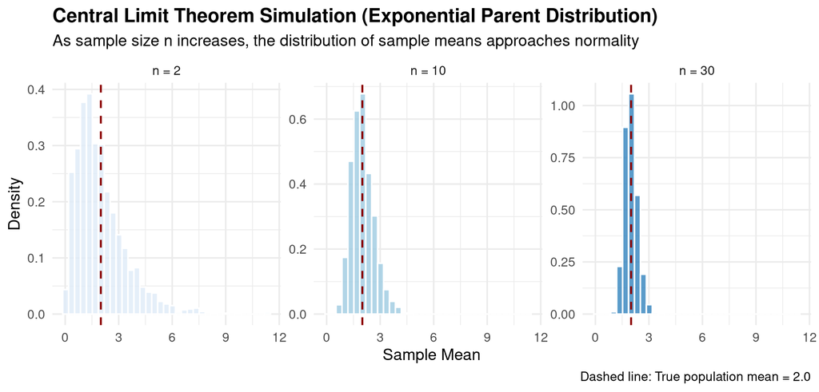

Figure 1

## Reproducible Python simulation

**Show the Python code**

```python
import numpy as np
import matplotlib.pyplot as plt

rng = np.random.default_rng(310)
replications = 2000
sample_sizes = [2, 10, 30]

fig, axes = plt.subplots(1, 3, figsize=(10, 4.5), sharey=False)

for ax, n in zip(axes, sample_sizes):
    samples = rng.exponential(scale=2.0, size=(replications, n))
    means = samples.mean(axis=1)

    ax.hist(means, bins=35, density=True, color="#2b7bba", edgecolor="white", alpha=0.85)
    ax.axvline(2.0, color="#b22222", linestyle="--", linewidth=1.5)
    ax.set_title(f"Sample Size n = {n}", fontsize=12, fontweight="bold")
    ax.set_xlabel("Sample Mean")
    ax.grid(color="#e0e0e0", linestyle=":", linewidth=0.8)
    ax.spines[["top", "right"]].set_visible(False)

axes[0].set_ylabel("Density")
fig.suptitle("Python Simulation: Central Limit Theorem (Exp λ=0.5)", fontsize=14, fontweight="bold")
fig.text(0.98, 0.01, "Dashed line: True mean = 2.0", ha="right", fontsize=9)
fig.tight_layout(rect=(0, 0.04, 1, 0.95))
plt.show()
```

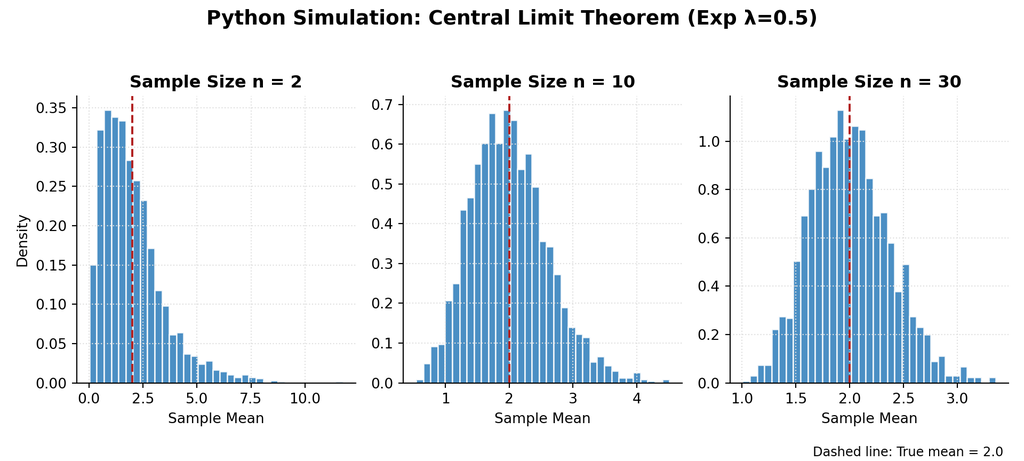

Figure 2

## Choosing the right tool for the job

| Scenario | Best Tool | Why |
| --- | --- | --- |
| **Quick code review or snippet explanation** | ChatGPT Desktop App | Fast keyboard shortcut, instant floating window over IDE |
| **Collaborative lesson planning in Google Docs** | Google Gemini App | Native Workspace integration, shared drive access |
| **Multi-file R/Quarto project development** | Google Antigravity | Full filesystem awareness, runs `quarto render`, verifies outputs |
| **Statistical data cleaning & exploratory analysis** | ChatGPT (Codex) / Antigravity | Automated sandbox execution and plotting |
| **Offline / Sensitive research data** | Local Models (via Ollama / Antigravity) | Zero external data transmission |

## Privacy, Security & Data Safety

When using Desktop Apps with local files:

- **Understand Where Code Runs:**
  - *ChatGPT Desktop:* Files uploaded are processed in OpenAI’s secure cloud sandbox.
  - *Google Gemini:* Processed in Google’s cloud.
  - *Antigravity:* Orchestrates tools locally on your workstation with explicit permission gates.
- **FERPA & Institutional Data:**
  - Never upload student grades, PII (Personally Identifiable Information), or sensitive research data to public models.
  - Check whether your university’s Enterprise agreement includes a **zero-data-retention (ZDR)** policy.
- **Inspect Generated Scripts Before Running:**
  - Always read shell or database scripts before executing them on production machines.

## Practical tips for local file workflows

1. **Organize Clean Project Directories:**
   - Keep datasets in `./data/`, scripts in `./R/` or `./scripts/`, and reports in the project root.
2. **Provide Data Schema First:**
   - Paste `str(df)` or `glimpse(df)` to give the AI the exact column names and types before asking for analysis code.
3. **Use Explicit Output Constraints:**
   - Mention your preferred packages (e.g., `tidyverse`, `ggplot2`, `broom`) and formatting rules (e.g., native pipe `|>`, Quarto HTML).
4. **Leverage Version Control (Git):**
   - Commit before having an agent perform large refactors so you can easily review diffs.

## Key takeaways

- **Desktop Apps** provide immediate, friction-free access compared to browser tabs.
- **ChatGPT with Codex** provides a powerful cloud sandbox for interactive data analysis and plotting.
- **Google Gemini** connects deeply with Google Workspace and general multimodal tasks.
- **Google Antigravity** provides an autonomous, local-first agentic workspace capable of editing, building, and verifying complete projects.
- **Context, privacy, and verification** remain essential whenever connecting AI to local files and research data.

## References

All links were accessed October 2026.

- OpenAI: [ChatGPT Desktop App](https://chatgpt.com/download/), [Working with Files in ChatGPT](https://help.openai.com/en/articles/8555545-file-uploads-in-chatgpt), and [OpenAI Codex](https://openai.com/codex/)
- Google: [Google Gemini Desktop](https://gemini.google/desktop/), [Gemini in Google Workspace](https://workspace.google.com/solutions/ai/), and [Google Antigravity](https://antigravity.google/)
- Quarto & R: [Quarto Revealjs Presentations](https://quarto.org/docs/presentations/revealjs/), [Tidyverse Ecosystem](https://www.tidyverse.org/), and [R-Core Team](https://www.r-project.org/)

Product availability and features may vary depending on university licensing, operating system, and administrative settings.

## Questions and discussion

What local file workflows or AI desktop tools are you most excited to explore?

**Date:** October 22, 2026 | **Time:** 12:15–1:15 PM  
**Zoom:** https://csueb.zoom.us/j/88674490934